# Algorithm Class 4 - Practice 2

Classes, objects, and references - II

May/29/2019

# 1 Static

Members (fields, methods, classes) belong to class, not object. (https://stackoverflow.com/questions/413898/what-does-the-static-keyword-do-in-a-class)

What do you mean by “belong to class, not instance”?

```java
LaiOfferManager sunLaoShi = new LaiOfferManager();
sunLaoShi.name = "Sun";
sunLaoShi.salary = 9999999;
LaiOfferManager zhaoLaoShi = new LaiOfferManager();
zhaoLaoShi.name = "Zhao";
zhaoLaoShisalary = 1000000;
```

Each teacher has one’s own name and salary.

```java
LaiOfferManager.meetingSoftware = new Zoom();
LaiOfferManager.isRich = false;
```

Note: we do not need an instance to access those (static) fields. These fields belong to the class.

```java
public class LaiOfferManager {
  public static void ipo() {
    isRish = true;
  }
  public void test() {
    name = "test";
    salary = salary + 1000;
  }
}
...
LaiOfferManager.ipo();
```

The behavior `ipo()` also belong to the whole class, but not any instance. Of course, it can only operate fields that belong to the class, but not instances (static fields).

## 1.1 Class variable v.s. Instance variable / Class method v.s. Instance method

```java
public class Solution {
  static int result = 0;
  public static void sort() { // 但static有很大局限
    result = 100;
  }
  public static void main(String[] args) {
    sort();
  }
}
```

```java
public class Solution {
  int result = 0;
  public void sort() {
    result = 100;
  }
  public static void main(String[] args) {
    Solution s = new Solution();
    s.sort();
  }
}
```

```java
Solution.main(args);
```

# 2 Final

Constants. “Once assigned, cannot be changed.”

- Final **class**: A class that cannot be derived (不可以繼承).
- Final **method**: A method that cannot be overridden (不可以修改).
- Final **variable**: A variable that once assigned, cannot be assigned again.

Enforced invariance, instead of this:

```java
// Don't change the value!
int value = 5;
...
...
value = getValueFromInput();
```

Using:

```java
final int value = 5;
```

What is the implication of this?

```java
public class Boy extends Student {
  ...
  final Student girlFriend;
  public Boy(Student gf) {
    girlFriend = gf;
  }
  ...
}
```

Can we do this?

```java
Boy b = new Boy(new Girl("taylor"));
b.girlFriend = new Girl("gaga");  // error!!!
```

- No.

Or this?

```java
Boy b = new Boy(new Girl("taylor"));
b.girlFriend.setName("gaga");
```

- Yes.

# 3 Java Parameter Passing

What is parameter passing?

```java
void foo(int a) {
  System.out.println(a * a);
}
...
foo(5);
...
```

We’re passing int value 5 to method `foo(int)`.

How to actually “pass”?

- Java is always pass by value (copy).
  - primitive type: **copy** of the **value itself**
  - objects: **copy** of the object **reference**

What is the implication?

```java
public class Simple {
  public int value;

  public Simple(int v) {
    value = v;
  }
}
```

1. `changeSimpleValue1`:

```java
public class ChangeTest {
  public static void main(String[] args) {
    Simple originalSimple = new Simple(5);  // originalSimple指向值為5的object
    changeSimpleValue1(originalSimple);
    System.out.println(originalSimple.value);
  }

  private static void changeSimpleValue1(Simple simple) {
    Simple newSimple = new Simple(10);
    simple = newSimple;
  }
}
```

- result: 5

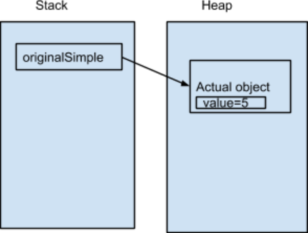

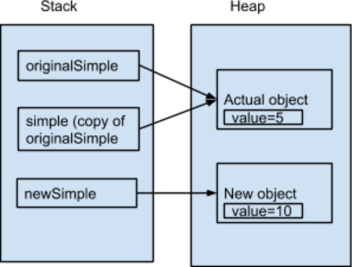

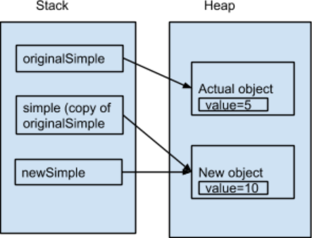

2. `changeSimpleValue2`:

```java
public class ChangeTest {
  public static void main(String[] args) {
    Simple originalSimple = new Simple(5);
    changeSimpleValue2(originalSimple);
    System.out.println(originalSimple.value);
  }

  private static void changeSimpleValue2(Simple simple) {
    simple.value = 10;  // 通過deref修改了heap上的值
  }
}
```

- result: 10

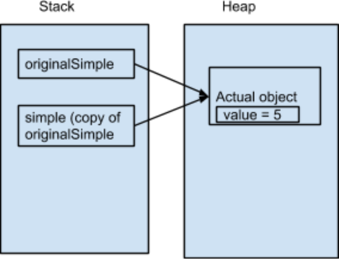

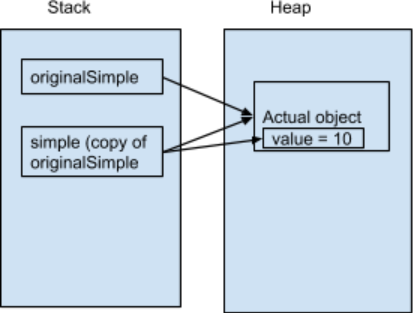

3. `changeSimpleValue3`:

```java
public class ChangeTest {
  public static void main(String[] args) {
    Simple originalSimple = new Simple(5);
    changeSimpleValue3(originalSimple);
    System.out.println(originalSimple.value);
  }

  private static void changeSimpleValue3(Simple simple) {
    Simple newSimple = new Simple(10);
    return newSimple;
  }
}
```

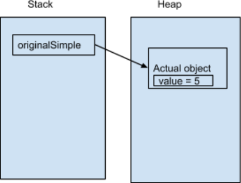

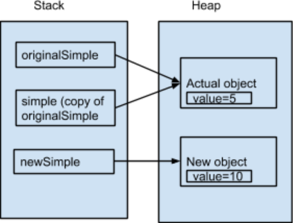

[figure not shown]

4. `changeIntValue(int x)`:

```java
public class ChangeTest {
  public static void main(String[] args) {
    int x = 5;
    changeIntValue(x);
    System.out.println(x);
  }

  private static void changeIntValue(int x) {
    x = 10;
  }
}
```

- result: 5

# 4 Array v.s. objects

What are arrays in Java? How are they stored in memory?

- Arrays are **Objects**.
- I cannot find the class for arrays…
  - True, the class declaration is not visible, but there still exists a class inside JVM.
  - Each of the arrays created is an instance of that class.
  - Remember “**new**” - it implies that there is a new object created.
- The elements in the array still occupy consecutive memory space on the heap.
- **`length` is a field of the array object** (array的`length`是個field, 沒有`()`)
- **array length cannot be changed after the array object is created. (final)**

```java
int[] array = new int[3];
array.length;
```

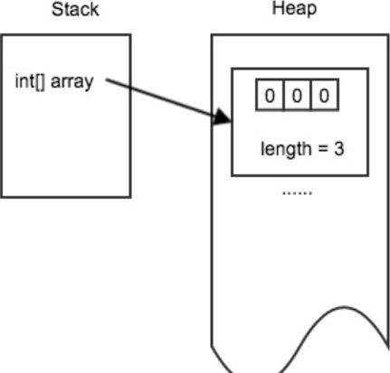

```java
int[][] array = new int[2][];
```

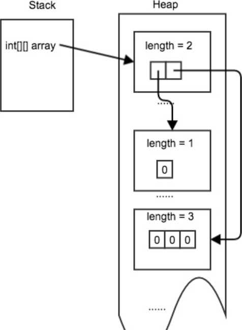

```java
int[][][] array = new int[2][3][4];
array  // int[][][]
array[1]  // int[][]
array[1][2] // int[]
array[1][2][3]  // int
```

Occupies consecutive memory and the elements in the array can be referenced via the index O($1$) time.

```java
int[] array = new int[3]; // {0, 0, 0}

int[] array = {1, 2, 3};  // {1, 2, 3}

int[] array = new int[] {1, 2, 3, 4, 5};  // {1, 2, 3, 4, 5}

int[] array;
array = new int[] {1, 2, 3};  // {1, 2, 3}
```

## 4.1 Exceptions/Errors

1. **`ArrayIndexOutOfBoundException!`**

If the index specified is not in the valid range of the array.

```java
int[] array = new int[] {5};
int value = array[5]; // ArrayIndexOutOfBoundException!
```

2. **`NullPointerException!`**

- **Dereference null**

```java
int[] array = null;
int value = array[1];

int[][] array = new int[5][]; // {null, null, null, null, null}
int[] v1 = array[6];  // ArrayIndexOutOfBoundException!
int v2 = array[3][2]; // NullPointerException!
```

```
dict.get(i) == null

dict.get(i) > target
  Integer       int

dict.get(i).intValue() > target
==> NPE!!!
```